# Simulating Random Variables

Lecture 10

February 26, 2024

# Review

## Bayesian Statistics

- Focused on conditional probability (conditioned on the data)
- Bayes’ Theorem to update priors using likelihood.
- Priors can be finicky: use predictive simulations.
- Outstanding question: how do we sample from the posterior (versus just taking the MAP?)

# Random Variable Simulation

## Why Simulate?

- We want to see implications of a probability model.
- We want to test statistical procedures (synthetic data simulation).
- Easier than computing integrals (Monte Carlo).
- Computational efficiency (*e.g.* stochastic gradient descent).

**Generally**: Turns calculus/analytical problems into data summary problems.

## Example: Posterior Sampling

$p(\theta)$ and $p(y | \theta)$ are often “nice” distributions, but nothing says
$$p(\theta | y) \propto p(\theta) \times p(y | \theta)$$

has to be!

```julia
normal_samples = rand(Normal(2, 0.5), 10)

lik(σ) = prod(pdf(Normal.(2, σ), normal_samples))
prior(σ) = pdf(LogNormal(log(0.25), 0.25), σ)
posterior(σ) = lik(σ) * prior(σ)

σ_range = 0.1:0.01:1
plot(σ_range, posterior.(σ_range) / maximum(posterior.(σ_range)), color=:black, label="Posterior", linewidth=3)
plot!(σ_range, lik.(σ_range) / maximum(lik.(σ_range)), color=:blue, label="Likelihood", linewidth=3, linestyle=:dash)
plot!(σ_range, prior.(σ_range) / maximum(prior.(σ_range)), color=:orange, label="Prior", linewidth=3, linestyle=:dot)
xlabel!(L"$\sigma$")
ylabel!("Scaled Log-Density")
plot!(size=(550, 500))
```

[figure not shown]

Figure 1: Comparison of prior, posterior, and likelihood.

## Built-In Sampling Functions

**R**: `sample`, `rnorm`, `rbinom`, etc.

**Julia**: `rand`, `Distributions.rand`

**Python**: `numpy.random.rand`, `scipy.stats.xx.rand`

## What Are These Functions Doing?

Think of a **biased coin with probability of heads $\theta$**.

Want to obtain a Bernoulli random variable.

**What can we do without using a built-in Bernoulli function**?

## Coin Flip Simulation

Given heads probability $\theta$:

1. Draw $u \sim Uniform(0, 1)$.
2. If $u < \theta$, return `H`.
3. Else return `T`.

## What About Discrete Variables?

How can we generalize this strategy for discrete distributions with category probabilities $\theta_1, \theta_2, \ldots, \theta_n$?

## Discrete Variable Simulation

Given category probabilities $\theta_1, \theta_2, \ldots, \theta_n$:

1. Draw $u \sim Uniform(0, 1)$.
2. If $u < \theta_1$, return 1.
3. If $u < \theta_1 + \theta_2$, return 2,
4. $\vdots$
5. Else return $n$.

## Generalization: Quantile Transform Method

Given $U \sim Uniform(0, 1)$, target CDF $F$, **$X = F^{-1}(U)$ has CDF $F$**.

Why?

$$\mathbb{P}(X \leq a) = \mathbb{P}(F^{-1}(U) \leq a) = \mathbb{P}(U \leq F(a)) = F(a)$$

In other words, if we can generate uniform variables and calculate quantiles, can generate non-uniform variables.

## Problem Solved…Right?

- Often don’t have quantile functions in closed form.
- They also often don’t have nice numerical solutions.

## Using the PDF

Suppose the PDF $f$ has support on $[a, b]$ and $f(x) \leq M$.

**What could we do to sample $X \sim f(\cdot)$?

[figure not shown]

Figure 2: Beta Distribution

## Rejection Sampling Algorithm

Given pdf $f$ for $X$, upper bound $M$ on $f$ in $[a, b]$:

1. Simulate uniformly: $y \sim [a, b]$, $u \sim [0, 1]$.
2. If $Mu < f(y)$, keep $y$ as a sample of $X$.
3. Otherwise reject.

## Rejection Sampling Visualization

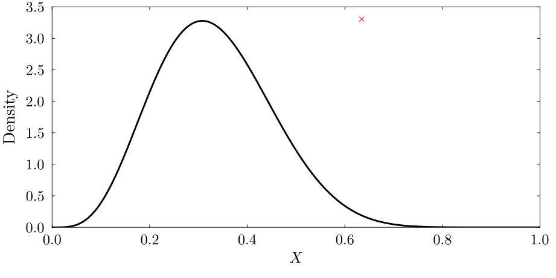

Figure 3: Example of rejection sampling for a Beta distribution

## Rejection Sampling Efficiency

**Important**: Only kept 27% of proposals.

[figure not shown]

(a) Results from uniform rejection sampling

[figure not shown]

(b)

Figure 4

## More General Rejection Sampling

Use a **proposal density** $g(\cdot)$ which “covers” target $f(\cdot)$ and is easy to sample from.

Sample from $g$, reject based on $f$.

[figure not shown]

Figure 5: Using a t distribution as proposal density for normal.

## General Rejection Sampling Algorithm

Suppose $f(x) \leq M g(x)$ for some $1 < M < \infty$.

1. Simulate a proposal $y \sim g(x)$ (*e.g.* by quantile method).
2. Simulate $u \sim \text{Unif}(0, 1)$
3. If
   $$u < \frac{f(y)}{M g(y)},$$
   accept $y$; otherwise reject.

## Rejection Sampling Example

[figure not shown]

Figure 6: Example of rejection sampling for a Normal distribution

This time we kept 35% of the proposals.

## Rejection Sampling Efficiency

1. Probability of accepting a sample is $1/M$, so the “tighter” the proposal distribution coverage the more efficient the sampler.
2. Need to be able to compute $M$ and sample from the proposal.

Finding a good proposal and computing $M$ may not be easy (or possible) for complex distributions!

## Bimodal Rejection Sampling Example

```julia
# specify target distribution
mixmod = MixtureModel(Normal, [(-1, 0.75), (1, 0.4)], [0.5, 0.5])
x = -5:0.01:5
p1 = plot(x, pdf.(mixmod, x), lw=3, color=:red, xlabel=L"$x$", ylabel="Density", label="Target")
plot!(p1, x, 2.5 * pdf.(Normal(0, 1.5), x), lw=3, color=:blue, label="Proposal (M=2.5)")
plot!(p1, size=(550, 500))

nsamp = 10_000
M = 2.5
u = rand(Uniform(0, 1), nsamp)
y = rand(Normal(0, 1.5), nsamp)
g = pdf.(Normal(0, 1.5), y)
f = pdf.(mixmod, y)
keep_samp = u .< f ./ (M * g)
p2 = histogram(y[keep_samp], normalize=:pdf, xlabel=L"$x$", ylabel="Density", label="Kept Samples", legend=:topleft)
plot!(p2, x, pdf.(mixmod, x), linewidth=3, color=:black, label="True Target")
density!(y[keep_samp], label="Sampled Density", color=:red)
plot!(p2, size=(550, 500))

display(p1)
display(p2)
```

[figure not shown]

(a) rejection sampling for a mixture model

[figure not shown]

(b)

Figure 7

# Random Number Generators

## Where Do “Random” Samples Come From?

There’s no such thing as a truly random number generator!

Need to generate samples in a deterministic way that have random-like properties.

[figure not shown]

XKCD Cartoon 221

Source: [XKCD 221](https://xkcd.com/221)

## Pseudorandom Number Generators

We want:

- Number of $U_i \in [a, b] \subset [0, 1]$ is $\propto b-a$
- No correlation between successive $U_i$.
- No detectable dependencies in longer series.

There are several of these implemented in modern programming languages: typical default is the **Mersenne Twister**.

## Example: Rotations

$$U_{t+1} = U_t + \alpha \mod 1$$

- If $\alpha \neq k/n$ is irrational, this never repeats (no $m$ such that $m\alpha = 1$.)
- If $\alpha = k/n$ is rational, this repeats, but with a long period for large $n$.

## (P)RNGs and Chaos

We can get similar dynamics from area-preserving **chaotic** dynamical systems:

- Long periods with dense orbits (well-mixing);
- Area-perserving (uniformly distributed);
- Rapid divergence of nearby points (sensitivity to initial conditions);

## Example: Arnold Cat Map

Report only $(U_t)$: get hard to predict uniformly distributed data.

[figure not shown]

Arnold Cat Map

Source: [Wikipedia](https://en.wikipedia.org/wiki/Arnold%27s_cat_map#The_discrete_cat_map)

## Cat Map vs Mersenne Twister

```julia
function cat_map(N)
    U = zeros(N)
    ϕ = zeros(N)
    U[1], ϕ[1] = rand(Uniform(0, 1), 2)
    for i = 2:N
        ϕ[i] = rem(U[i-1] + 2 * ϕ[i-1], 1.0)
        U[i] = rem(U[i-1] + ϕ[i-1], 1.0)
    end
    return U
end

N = 1_000
Z = cat_map(N)
U = rand(MersenneTwister(1), N) # Mersenne Twister is not the default in Julia, but is in other languages, so using it here by explicitly setting it as the generator

p1 = scatter(Z[1:end-1], Z[2:end], xlabel=L"$U_t$", ylabel=L"$U_{t+1}$", title="Cat Map", label=false, size=(500, 500))
p2 = scatter(U[1:end-1], U[2:end], xlabel=L"$U_t$", ylabel=L"$U_{t+1}$", title="Mersenne Twister", label=false, size=(500, 500))

display(p1)
display(p2)
```

[figure not shown]

(a) Comparison of the Arnold cat map and output from the Mersenne Twister

[figure not shown]

(b)

Figure 8

## Random Seeds

Pseudo-random numbers are deterministic, so can be repeated. The sequence depends on a **seed**.

- If you don’t set a seed explicitly, the computer will choose one (usually based on the date/time stamp when you execute the script or program).
- Setting a seed resets the sequence.

**Set seeds to ensure reproducibility**.

## But…Be Careful With Seeds

- Possible for a statistical procedure to appear to work with just one seed; **test across several**.
- Seeds may match, but RNG algorithm may be different across different languages/versions.

# Key Points and Upcoming Schedule

## Key Points: Bayesian Statistics

- Use prior predictive simulations to refine priors.
- Priors matter less when likelihood is highly informative.

## Key Points: Random Numbers

- Can generate uniform distributions using pseudorandom number generators (unstable dynamical systems).
- Transform into other distributions using:
  - Quantile method;
  - Rejection method.
- Default functions work well; only really have to worry about any of this when sampling from “non-nice” distributions

# Upcoming Schedule

## Next Classes

**Next Week**: Monte Carlo Simulation and the Bootstrap

## Term Project

- Can work in groups of 1-2
- Proposal due 3/21.
- Max three pages, should include background and problem statement, data overview, proposed probability models, and research plan.
- Deliverables include presentations (in class, last 2-3 sessions) and written report (during finals week).

# References